# Trabajo de Alicja

Universitat de València

Diciembre de 2021 (actualizado el 19-11-2021)

Trabajo elaborado para la asignatura “Programación y manejo de datos en la era del Big Data” de la Universitat de València durante el curso 2021-2022. El repo del trabajo está [aquí](https://github.com/AlicjaMl/trabajo_BigData).

La página web de la asignatura y los trabajos de mis compañeros pueden verse [aquí](https://perezp44.github.io/intro-ds-21-22-web/07-trabajos.html).

# 1. Introducción

Początek pracy

La introducción **es una de las partes importantes del trabajo**. En la introducción suele ponerse el objetivo, motivación, un pequeño resumen del trabajo y avance de conclusiones si es que hay.

```r
2 + 2
```

```
#> [1] 4
```

Yo no usaría CSS, bastante trabajo tenéis, pero … si usas CSS para tunear tu html podrás dejarlo más bonito, o al menos más a tu gusto. Por ejemplo, podrás fácilmente cambiar el tamaño de algunas palabras, por ejemplo, **unas palabras en grande y en negrita**, aunque si estas usando CSS saldrán en verde porque en el CSS he puesto que la negrita salga en verde. Por ejemplo, podrás poner fácilmente unas palabras en purple, y ahora, en grande y en rojito.

# 2. Datos

Una parte **importante** del trabajo es explicar **de donde proceden los datos** y cual ha sido el proceso de limpieza

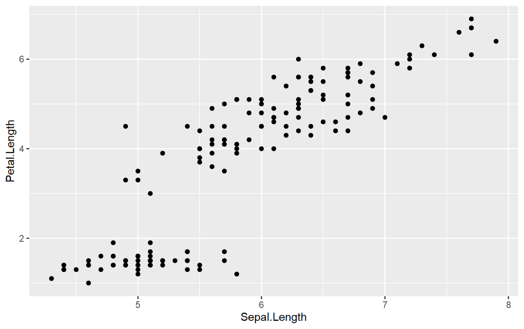

```r
ggplot(iris, aes(Sepal.Length, Petal.Length)) + geom_point()
```

## 2.1. Procesando los datos

Pues eso que tenéis que contar (un poco) el procesado de datos

```r
DT::datatable(iris)
```

|  | Sepal.Length | Sepal.Width | Petal.Length | Petal.Width | Species |
| --- | --- | --- | --- | --- | --- |
| 1 | 5.1 | 3.5 | 1.4 | 0.2 | setosa |
| 2 | 4.9 | 3 | 1.4 | 0.2 | setosa |
| 3 | 4.7 | 3.2 | 1.3 | 0.2 | setosa |
| 4 | 4.6 | 3.1 | 1.5 | 0.2 | setosa |
| 5 | 5 | 3.6 | 1.4 | 0.2 | setosa |
| 6 | 5.4 | 3.9 | 1.7 | 0.4 | setosa |
| 7 | 4.6 | 3.4 | 1.4 | 0.3 | setosa |
| 8 | 5 | 3.4 | 1.5 | 0.2 | setosa |
| 9 | 4.4 | 2.9 | 1.4 | 0.2 | setosa |
| 10 | 4.9 | 3.1 | 1.5 | 0.1 | setosa |

[output cut: 140 more lines]

# 3. Trabajos en los que te has basado

Es importante que, si habéis utilizado, os habéis basado/ayudado, de algún análisis previo de otro autor, lo digáis claramente.

Por ejemplo, está cita es de NV

> “Nadie llega tan lejos si no es para seguir”

# 4. RECUERDA!!!

Recuerda que **tienes que mandarme un mail** con tu nombre, usuario de Github y nombre de tu trabajo

Recuerda que el repo de Github **se ha de llamar EXACTAMENTE** “trabajo_BigData”

Por favor, **no cambies el primer párrafo**. Sirve para dar contexto al trabajo y remitir a los potenciales lectores a la web del curso y poder ver los otros trabajos. Bueno, si que has de cambiar algo: **has de sutituir “perezp44” por tu usuario de Github**, tanto en el archivo index.Rmd como en el Readme.Rmd

R️ecuerda, el 7 de enero fecha límite para la entrega.

SUERTE!!!! 🧙‍♀️🧙‍♀️